# Pronosticos_30_Mayo_Ibarra_Sergio_Concentracion

#### Se ‘entrena’ (en este caso, se define) al modelo lineal ‘simple’ con los datos de train

```r
modelo_lineal_simple1_concentracion_datos_original <- glm (concentracion_datos_original_ts_train ~  rep_mes + tend, data=concentracion_datos_original_ts_train_frame, family = gaussian(link = identity))
modelo_lineal_simple1_concentracion_datos_original
```

```
##
## Call:  glm(formula = concentracion_datos_original_ts_train ~ rep_mes +
##     tend, family = gaussian(link = identity), data = concentracion_datos_original_ts_train_frame)
##
## Coefficients:
## (Intercept)   rep_mesago   rep_mesdic   rep_mesene   rep_mesfeb   rep_mesjul
##    332.8734      -4.0619      -3.6047      -2.7419      -2.0974      -1.9156
##  rep_mesjun   rep_mesmar   rep_mesmay   rep_mesnov   rep_mesoct   rep_messep
##     -0.2043      -1.1337       0.3662      -4.8492      -6.0488      -5.8924
##        tend
##      0.1222
##
## Degrees of Freedom: 143 Total (i.e. Null);  131 Residual
## Null Deviance:       4227
## Residual Deviance: 19.2  AIC: 146.5
```

Se obtiene el summary y plot del modelo lineal ‘simple’

```r
summary(modelo_lineal_simple1_concentracion_datos_original)
```

```
##
## Call:
## glm(formula = concentracion_datos_original_ts_train ~ rep_mes +
##     tend, family = gaussian(link = identity), data = concentracion_datos_original_ts_train_frame)
##
## Deviance Residuals:
##      Min        1Q    Median        3Q       Max
## -0.94202  -0.23786   0.02412   0.28580   0.78874
##
## Coefficients:
##               Estimate Std. Error  t value Pr(>|t|)
## (Intercept)  3.329e+02  1.230e-01 2707.265  < 2e-16 ***
## rep_mesago  -4.062e+00  1.563e-01  -25.986  < 2e-16 ***
## rep_mesdic  -3.605e+00  1.564e-01  -23.048  < 2e-16 ***
## rep_mesene  -2.742e+00  1.563e-01  -17.542  < 2e-16 ***
## rep_mesfeb  -2.097e+00  1.563e-01  -13.420  < 2e-16 ***
## rep_mesjul  -1.916e+00  1.563e-01  -12.256  < 2e-16 ***
## rep_mesjun  -2.043e-01  1.563e-01   -1.307   0.1934
## rep_mesmar  -1.134e+00  1.563e-01   -7.254 3.17e-11 ***
## rep_mesmay   3.662e-01  1.563e-01    2.343   0.0206 *
## rep_mesnov  -4.849e+00  1.564e-01  -31.010  < 2e-16 ***
## rep_mesoct  -6.049e+00  1.564e-01  -38.687  < 2e-16 ***
## rep_messep  -5.892e+00  1.563e-01  -37.692  < 2e-16 ***
## tend         1.222e-01  7.701e-04  158.621  < 2e-16 ***
## ---
## Signif. codes:  0 '***' 0.001 '**' 0.01 '*' 0.05 '.' 0.1 ' ' 1
##
## (Dispersion parameter for gaussian family taken to be 0.1465455)
##
##     Null deviance: 4226.747  on 143  degrees of freedom
## Residual deviance:   19.197  on 131  degrees of freedom
## AIC: 146.49
##
## Number of Fisher Scoring iterations: 2
```

Vamos a proceder a plotear los residuos de mi modelo lineal

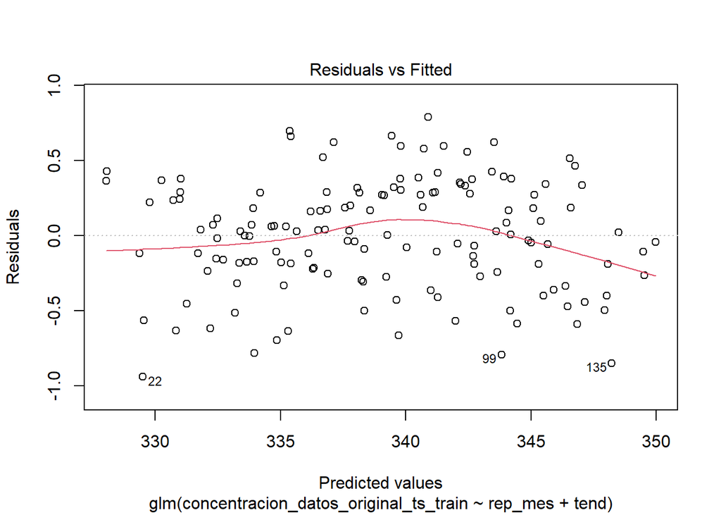

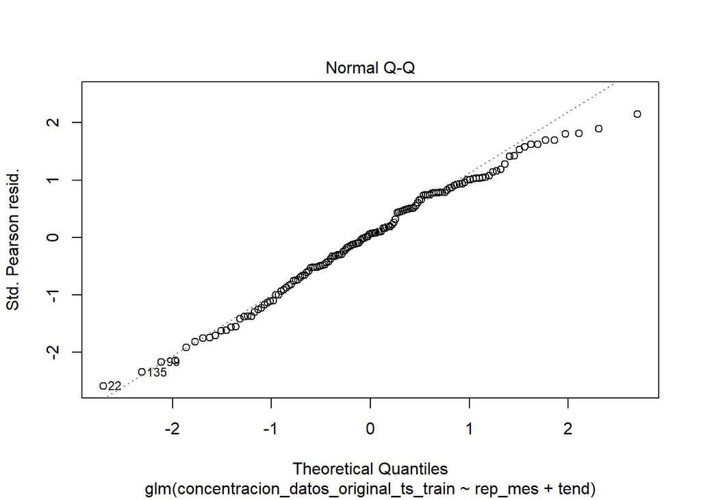

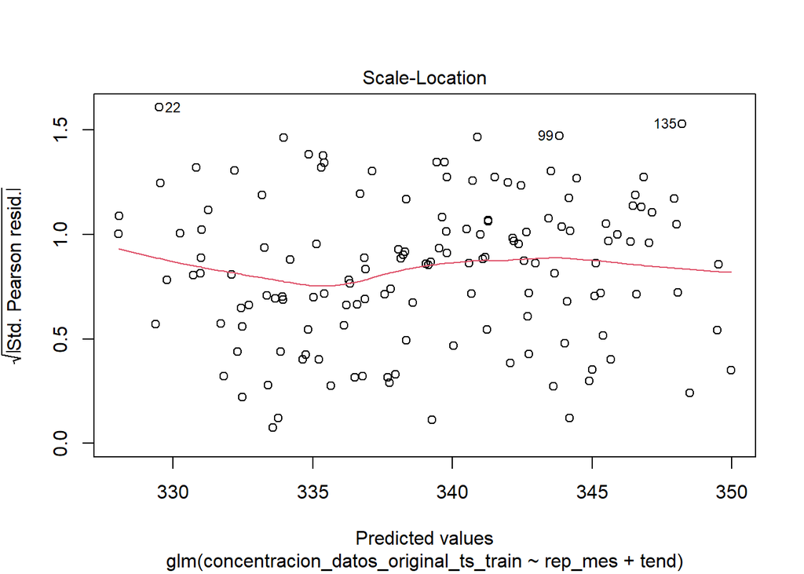

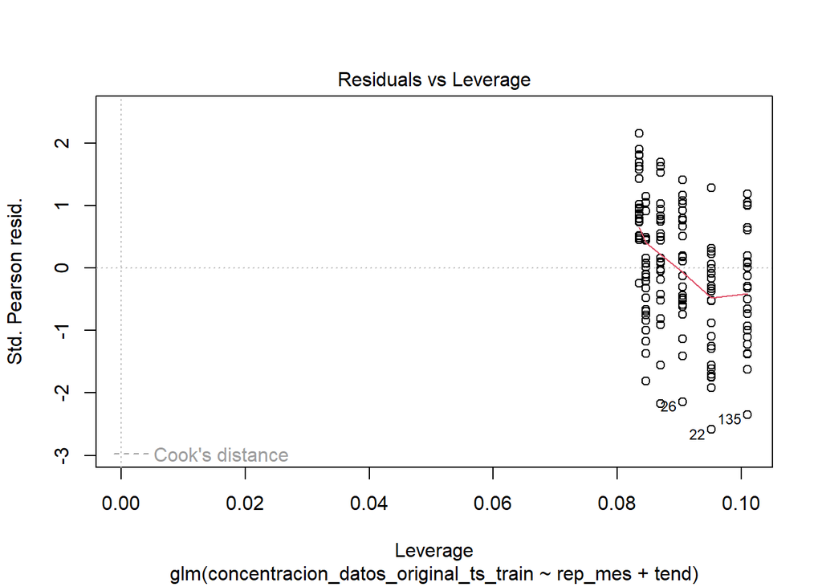

```r
plot(modelo_lineal_simple1_concentracion_datos_original)
```

Se observa que los reiduos no tienen pendiente definida, tendencia o siguen un patron establecido, en general se observa que las gráficas del error son muy buenas

#### Testeo del ‘modelo lineal generalizado simple’ haciendo la predición de los datos de test

```r
concentracion_datos_original_ts_test_frame <- data.frame(concentracion_datos_original_ts_test,rep_mes[145:154],tend[145:154])
head(concentracion_datos_original_ts_test_frame)
```

```
##   concentracion_datos_original_ts_test rep_mes.145.154. tend.145.154.
## 1                               347.33              ene           145
## 2                               347.82              feb           146
## 3                               349.29              mar           147
## 4                               350.91              abr           148
## 5                               351.71              may           149
## 6                               350.94              jun           150
```

```r
tail(concentracion_datos_original_ts_test_frame)
```

```
##    concentracion_datos_original_ts_test rep_mes.145.154. tend.145.154.
## 5                                351.71              may           149
## 6                                350.94              jun           150
## 7                                349.10              jul           151
## 8                                346.77              ago           152
## 9                                345.73              sep           153
## 10                                   NA              oct            NA
```

```r
dim(concentracion_datos_original_ts_test_frame)
```

```
## [1] 10  3
```

```r
concentracion_datos_original_ts_test_frame$rep_mes <-concentracion_datos_original_ts_test_frame$rep_mes.145.154.
concentracion_datos_original_ts_test_frame$rep_mes.145.154. <- NULL
concentracion_datos_original_ts_test_frame$tend <-concentracion_datos_original_ts_test_frame$tend.145.154.
concentracion_datos_original_ts_test_frame$tend.145.154. <- NULL

concentracion_datos_original_ts_test_frame
```

```
##    concentracion_datos_original_ts_test rep_mes tend
## 1                                347.33     ene  145
## 2                                347.82     feb  146
## 3                                349.29     mar  147
## 4                                350.91     abr  148
## 5                                351.71     may  149
## 6                                350.94     jun  150
## 7                                349.10     jul  151
## 8                                346.77     ago  152
## 9                                345.73     sep  153
## 10                                   NA     oct   NA
```

#### Calculo de predicción del ‘modelo lineal generalizado simple’ para los datos_original

```r
prediccion_modelo_lineal_simple1_concentracion_datos_original <- predict(modelo_lineal_simple1_concentracion_datos_original, newdata = concentracion_datos_original_ts_test_frame, se.fit = TRUE)


prediccion_modelo_lineal_simple1_concentracion_datos_original
```

```
## $fit
##        1        2        3        4        5        6        7        8
## 347.8438 348.6105 349.6963 350.9522 351.4405 350.9922 349.4030 347.3788
##        9       10
## 345.6705       NA
##
## $se.fit
##         1         2         3         4         5         6         7         8
## 0.1257786 0.1257786 0.1257786 0.1257786 0.1257786 0.1257786 0.1257786 0.1257786
##         9        10
## 0.1257786        NA
##
## $residual.scale
## [1] 0.3828126
```

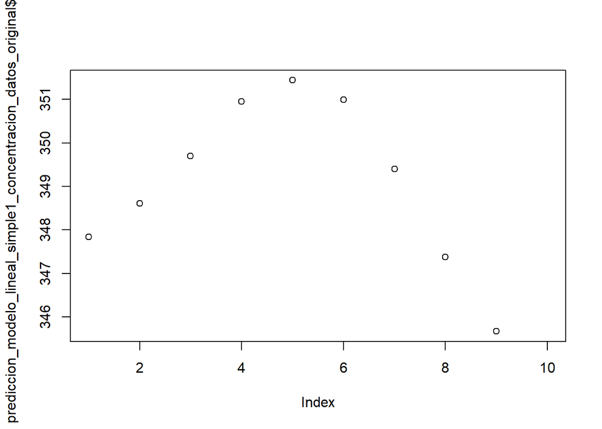

```r
plot(prediccion_modelo_lineal_simple1_concentracion_datos_original$fit)
```

#### Calculo de errores del ‘modelo lineal generalizado simple’ para los datos_original

```r
accuracy(concentracion_datos_original_ts_test , prediccion_modelo_lineal_simple1_concentracion_datos_original$fit)
```

```
##                 ME      RMSE       MAE       MPE       MAPE
## Test set 0.2653262 0.4212723 0.3384322 0.0761852 0.09704982
```

El MAPE del modelo lineal generalizado simple es MENOR que el de los métodos de SMA y WMA

## Modelo SARIMA para Datos_original

#### Determinación de ACF & PACF para el caso de la colorado_data_original (SIN ESTACIONALIZAR)

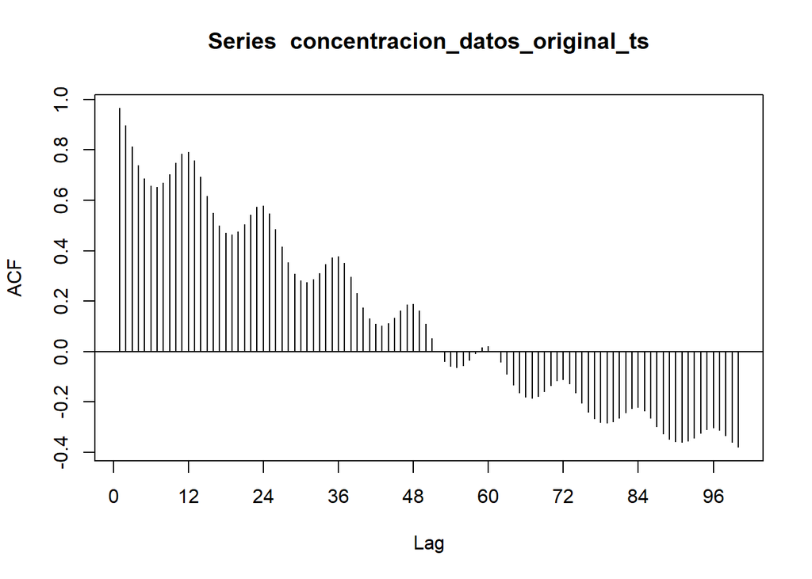

```r
#install.packages("forecast")
library(forecast)

#par(mfrow=c(2,1))

acf_concentracion_datos_original_ts_sin_diferenciar <- Acf(concentracion_datos_original_ts, lag.max = 100, ci.type = "ma")
```

```r
acf_concentracion_datos_original_ts_sin_diferenciar
```

```
##
## Autocorrelations of series 'concentracion_datos_original_ts', by lag
##
##      0      1      2      3      4      5      6      7      8      9     10
##  1.000  0.964  0.895  0.812  0.738  0.686  0.657  0.652  0.668  0.703  0.747
##     11     12     13     14     15     16     17     18     19     20     21
##  0.783  0.791  0.758  0.693  0.617  0.549  0.500  0.471  0.464  0.476  0.505
##     22     23     24     25     26     27     28     29     30     31     32
##  0.541  0.572  0.577  0.546  0.486  0.416  0.353  0.308  0.283  0.275  0.285
##     33     34     35     36     37     38     39     40     41     42     43
##  0.312  0.346  0.374  0.378  0.350  0.295  0.231  0.174  0.132  0.108  0.102
##     44     45     46     47     48     49     50     51     52     53     54
##  0.112  0.134  0.162  0.186  0.188  0.161  0.110  0.052  0.000 -0.038 -0.059
##     55     56     57     58     59     60     61     62     63     64     65
## -0.064 -0.055 -0.035 -0.007  0.016  0.021  0.001 -0.042 -0.090 -0.133 -0.164
##     66     67     68     69     70     71     72     73     74     75     76
## -0.181 -0.185 -0.177 -0.159 -0.135 -0.115 -0.111 -0.128 -0.163 -0.204 -0.241
##     77     78     79     80     81     82     83     84     85     86     87
## -0.266 -0.280 -0.284 -0.278 -0.263 -0.243 -0.226 -0.221 -0.234 -0.263 -0.296
##     88     89     90     91     92     93     94     95     96     97     98
## -0.326 -0.346 -0.357 -0.360 -0.353 -0.341 -0.324 -0.308 -0.302 -0.311 -0.332
##     99    100
## -0.358 -0.379
```

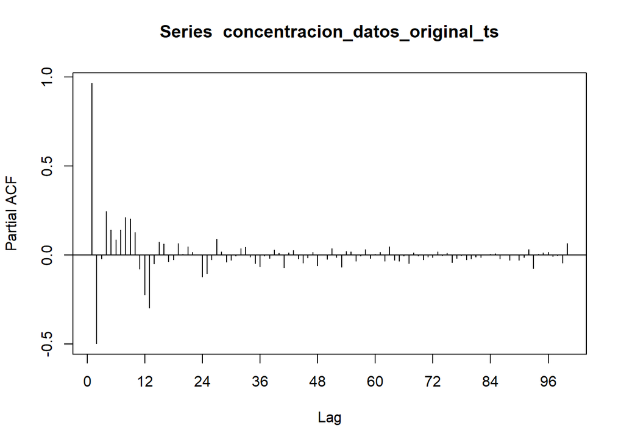

```r
pacf_datos_concentracion_original_ts_sin_diferenciar <- Pacf(concentracion_datos_original_ts, lag.max = 100, ci.type = "ma")
```

```r
pacf_datos_concentracion_original_ts_sin_diferenciar
```

```
##
## Partial autocorrelations of series 'concentracion_datos_original_ts', by lag
##
##      1      2      3      4      5      6      7      8      9     10     11
##  0.964 -0.498 -0.021  0.244  0.140  0.085  0.140  0.211  0.201  0.127 -0.078
##     12     13     14     15     16     17     18     19     20     21     22
## -0.224 -0.298 -0.050  0.072  0.063 -0.036 -0.028  0.066  0.005  0.046  0.014
##     23     24     25     26     27     28     29     30     31     32     33
##  0.002 -0.122 -0.106 -0.027  0.088  0.018 -0.039 -0.029 -0.006  0.037  0.043
##     34     35     36     37     38     39     40     41     42     43     44
## -0.010 -0.047 -0.067 -0.006 -0.020  0.028  0.010 -0.072  0.012  0.025 -0.021
##     45     46     47     48     49     50     51     52     53     54     55
## -0.044 -0.017  0.016 -0.061  0.003 -0.024  0.037 -0.014 -0.068  0.021  0.018
##     56     57     58     59     60     61     62     63     64     65     66
## -0.035 -0.006  0.030 -0.020  0.006  0.015 -0.033  0.046 -0.030 -0.035 -0.005
##     67     68     69     70     71     72     73     74     75     76     77
## -0.047  0.013 -0.005 -0.026 -0.012 -0.015  0.018 -0.003  0.009 -0.041 -0.019
##     78     79     80     81     82     83     84     85     86     87     88
## -0.004 -0.027 -0.021 -0.011 -0.015  0.001  0.005  0.006 -0.021  0.003 -0.029
##     89     90     91     92     93     94     95     96     97     98     99
##  0.003 -0.030 -0.014  0.032 -0.076  0.005  0.013  0.015 -0.009 -0.003 -0.044
##    100
##  0.063
```

La función ACF de la serie colorado, nos muestra claramente una forma de decaimiento constante. Hagamos una prueba de estacionariedad

#### Se lleva a cabo el tet de Dickey-Fulley (Ho: Serie no estacionaria) a la serie de datos_original

```r
# Install and load the "urca" package
#install.packages("urca")
library(urca)

# Perform ADF test for stationarity
adf_test_datos_concentracion_original_ts <- ur.df(concentracion_datos_original_ts)

# Print the ADF test results
summary(adf_test_datos_concentracion_original_ts)
```

```
##
## ###############################################
## # Augmented Dickey-Fuller Test Unit Root Test #
## ###############################################
##
## Test regression none
##
##
## Call:
## lm(formula = z.diff ~ z.lag.1 - 1 + z.diff.lag)
##
## Residuals:
##      Min       1Q   Median       3Q      Max
## -1.80220 -0.73838 -0.01379  0.59903  1.96024
##
## Coefficients:
##             Estimate Std. Error t value Pr(>|t|)
## z.lag.1    4.475e-05  2.167e-04   0.206    0.837
## z.diff.lag 7.067e-01  5.820e-02  12.143   <2e-16 ***
## ---
## Signif. codes:  0 '***' 0.001 '**' 0.01 '*' 0.05 '.' 0.1 ' ' 1
##
## Residual standard error: 0.9012 on 149 degrees of freedom
## Multiple R-squared:  0.5001, Adjusted R-squared:  0.4933
## F-statistic: 74.52 on 2 and 149 DF,  p-value: < 2.2e-16
##
##
## Value of test-statistic is: 0.2065
##
## Critical values for test statistics:
##       1pct  5pct 10pct
## tau1 -2.58 -1.95 -1.62
```

#### Vamos a diferenciar la serie de datos_orignal ‘para hacerlo estacionaria’

```r
# Calculate the difference between consecutive elements
datos_concentracion_original_ts_diferencia1 <- diff(concentracion_datos_original_ts, differences = 1)

# Print the results
print(datos_concentracion_original_ts_diferencia1)
```

```
##      Jan   Feb   Mar   Apr   May   Jun   Jul   Aug   Sep   Oct   Nov   Dec
## 1         0.78  0.47  1.31  0.74 -0.49 -1.58 -1.84 -1.50 -0.10  0.84  1.72
## 2   0.63  1.00  0.97  1.15 -0.04 -0.51 -1.21 -2.16 -1.82 -0.41  1.63  1.38
## 3   1.09  0.50  1.69  1.21  0.75 -0.70 -1.31 -2.25 -1.26 -0.08  1.15  1.12
## 4   1.22  0.52  1.31  1.25  0.16  0.05 -1.63 -1.90 -2.01 -0.17  1.47  1.04
## 5   1.20  0.63  1.30  1.02  0.10  0.22 -1.63 -1.96 -1.91  0.32  1.20  1.47
## 6   1.01  0.49  1.84  0.78  0.59 -0.16 -1.90 -1.67 -1.67  0.00  1.15  1.16
## 7   0.94  1.09  1.28  0.82  0.51 -0.48 -1.66 -2.13 -1.70  0.08  1.32  1.40
## 8   1.05  0.80  1.00  0.95  0.63 -0.86 -1.40 -2.05 -2.13  0.16  1.20  1.43
## 9   0.78  1.27  0.36  2.23  0.65 -0.52 -1.24 -2.05 -2.00  0.04  1.23  1.64
## 10  0.85  0.72  0.52  1.96  0.31 -0.60 -1.82 -2.25 -1.85  0.27  1.71  1.48
## 11  0.56  0.74  1.61  0.39  0.91 -0.66 -1.87 -2.14 -1.31  0.02  1.54  1.38
## 12  0.55  0.66  0.68  2.00  0.55 -0.67 -1.82 -1.89 -1.34 -0.54  1.42  1.18
## 13  1.06  0.49  1.47  1.62  0.80 -0.77 -1.84 -2.33 -1.04
```

#### ACF & PACF para los datos_original con 1 diferencia ‘estacionariazada’

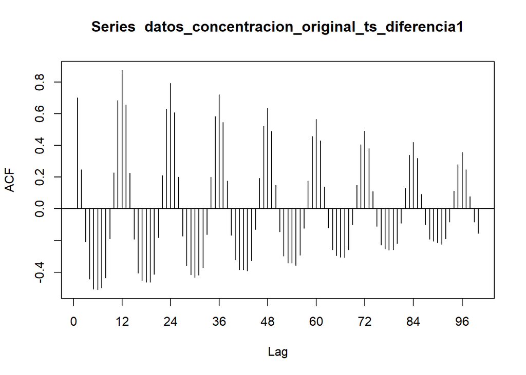

```r
library(forecast)

#par(mfrow=c(2,1))

acf_datos_concentracion_original_ts_diferencia1 <- Acf(datos_concentracion_original_ts_diferencia1, lag.max = 100, ci.type = "ma")
```

```r
acf_datos_concentracion_original_ts_diferencia1
```

```
##
## Autocorrelations of series 'datos_concentracion_original_ts_diferencia1', by lag
##
##      0      1      2      3      4      5      6      7      8      9     10
##  1.000  0.703  0.249 -0.210 -0.442 -0.508 -0.510 -0.500 -0.437 -0.190  0.228
##     11     12     13     14     15     16     17     18     19     20     21
##  0.683  0.875  0.658  0.226 -0.191 -0.405 -0.452 -0.463 -0.462 -0.412 -0.181
##     22     23     24     25     26     27     28     29     30     31     32
##  0.212  0.630  0.794  0.607  0.200 -0.173 -0.358 -0.415 -0.433 -0.418 -0.371
##     33     34     35     36     37     38     39     40     41     42     43
## -0.163  0.201  0.583  0.721  0.546  0.177 -0.166 -0.323 -0.385 -0.383 -0.391
##     44     45     46     47     48     49     50     51     52     53     54
## -0.326 -0.129  0.194  0.522  0.636  0.490  0.149 -0.144 -0.298 -0.342 -0.342
##     55     56     57     58     59     60     61     62     63     64     65
## -0.356 -0.292 -0.123  0.175  0.456  0.567  0.431  0.139 -0.120 -0.259 -0.294
##     66     67     68     69     70     71     72     73     74     75     76
## -0.304 -0.307 -0.258 -0.101  0.149  0.405  0.492  0.381  0.109 -0.109 -0.228
##     77     78     79     80     81     82     83     84     85     86     87
## -0.252 -0.261 -0.258 -0.218 -0.089  0.129  0.340  0.421  0.318  0.093 -0.099
##     88     89     90     91     92     93     94     95     96     97     98
## -0.191 -0.204 -0.214 -0.223 -0.188 -0.082  0.113  0.281  0.356  0.249  0.076
##     99    100
## -0.083 -0.154
```

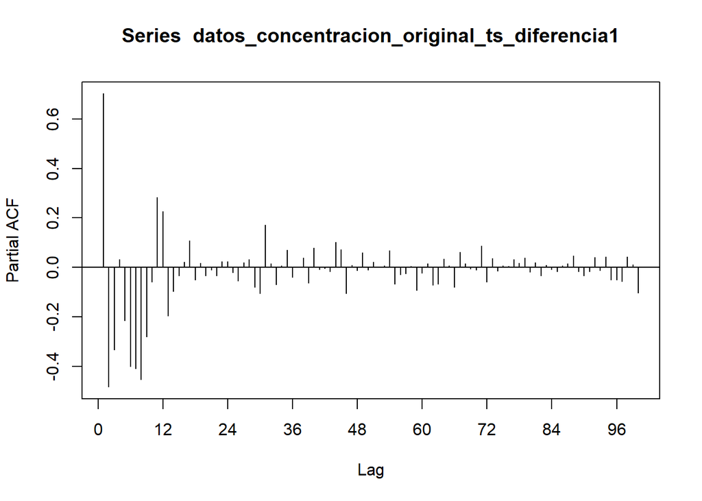

```r
pacf_datos_concentracion_original_ts_diferencia1 <- Pacf(datos_concentracion_original_ts_diferencia1, lag.max = 100, ci.type = "ma")
```

```r
pacf_datos_concentracion_original_ts_diferencia1
```

```
##
## Partial autocorrelations of series 'datos_concentracion_original_ts_diferencia1', by lag
##
##      1      2      3      4      5      6      7      8      9     10     11
##  0.703 -0.484 -0.333  0.031 -0.215 -0.402 -0.409 -0.453 -0.281 -0.058  0.283
##     12     13     14     15     16     17     18     19     20     21     22
##  0.226 -0.197 -0.097 -0.034  0.021  0.107 -0.050  0.017 -0.032 -0.011 -0.034
##     23     24     25     26     27     28     29     30     31     32     33
##  0.024  0.024 -0.020 -0.056  0.019  0.031 -0.079 -0.105  0.171  0.014 -0.069
##     34     35     36     37     38     39     40     41     42     43     44
##  0.006  0.071 -0.040  0.001  0.037 -0.063  0.079 -0.009 -0.003 -0.016  0.103
##     45     46     47     48     49     50     51     52     53     54     55
##  0.071 -0.106  0.009 -0.012  0.060 -0.011  0.021  0.003  0.006  0.069 -0.067
##     56     57     58     59     60     61     62     63     64     65     66
## -0.030 -0.025  0.004 -0.093 -0.023  0.015 -0.071 -0.068  0.034  0.007 -0.080
##     67     68     69     70     71     72     73     74     75     76     77
##  0.061  0.015 -0.006 -0.011  0.087 -0.059  0.037 -0.014  0.007  0.004  0.032
##     78     79     80     81     82     83     84     85     86     87     88
##  0.016  0.039 -0.018  0.020 -0.034  0.009 -0.008 -0.018  0.006  0.014  0.048
##     89     90     91     92     93     94     95     96     97     98     99
## -0.016 -0.033 -0.017  0.040 -0.012  0.042 -0.050 -0.051 -0.057  0.043  0.011
##    100
## -0.104
```

La diferenciación de la seria ayudó a hacerla estacionaria y además a que se puediera disntinguir tanto los valores significativos para la parte MA del ARIMA, como la estacionalidad marcada cada 12 meses

Con base en las gráficas de ACF y PACF se decide probar un modleo ARIMA (2,1,1)